# Tree Models

Jim Harner

7/25/2018

## 7.6 Other ML Algorithms

### 7.6.1 Basics

Spark 2.2 and `sparklyr` have many algorithms for classification. We have been exposed to logistic regression in Section 7.3. We will compare 6 classification algorithms in this chapter.

- Logistic Regression: models the posterior conditional probabilities of the $k$ classes by a linear functions in $X$, while ensuring that they sum to one and remain in [0,1]. The model is specified in terms of $k-1$ logit transformations with the last class as the denominator in the odds-ratios.
- Decision Tree (DT): use weak learners which output real values for splits. These outputs can be added together, allowing subsequent model outputs to be added and to correct the residuals in the predictions. Trees choose the best split points based on purity scores, e.g., Gini, or minimizing the loss. Regularization can be used to reduce overfitting. The output variable can be discrete (classification) or continuous (regression).
- Random Forests (RF): is an ensemble learner that combines bagging with random feature selection. Bagging (bootstrap aggregation) reduces the variance of a prediction model, e.g., a tree which tends to have high variance, but low bias.
- Gradient Boosted Trees (GBT): combines gradient-based optimization with boosting. Boosting additively collects an ensemble of weak learners to create a strong learner for prediction. Gradient boosting can be used for both regression and $k$-group classification.
- Naive Bayes (NB): are simple probabilistic classifiers based on applying Bayes’ theorem with strong (naive) independence assumptions between the features. It is often used when the dimension $p$ of the feature space is high.
- Neural Net (MLP): is a feedforward artificial neural network. An MLP has at least three layers of variables (nodes). Except for the input variables, each node uses a nonlinear activation function. MLP utilizes a supervised learning technique called backpropagation for training.

Note: Support Vector Machines (SVM) are not yet supported.

### 7.6.2 Model Comparison Wine Quality Example

We illustrate logistic regression modeling using the Wine Quality Data Set from the [UCI Machine Learning Repository](https://archive.ics.uci.edu/ml/datasets/wine+quality). The two datasets: the red and white variants of the Portuguese “Vinho Verde” wine, but we will restrict analysis to the red wine dataset.

The features (or predictors) are all numeric, whereas the labels (or the predictand) is a score ranging from 0 to 10 representing the wine quality. Technically, this is an ordered categorical model, but we will binarize the outcome variable at a threshold value of 5.0.

Read the `winequality-red.csv` file directory into a Spark DataFrame using `spark_red_sdf`.

```r
wine_red_sdf <- spark_read_csv(sc, "wine_red_sdf",
                               path = "file:///home/rstudio/rspark-tutorial/data/wine/winequality-red.csv",
                               delimiter = ";" )
wine_red_tbl <- sdf_register(wine_red_sdf, name = "wine_red_tbl")
```

We register the Spark DataFrame so that the Scala Spark DataFrame API is used directly rather than the `dplyr` interface. Registering forces the SQL to completion without using `collect`, which is necessary for the pipeline in the next chunk.

We split `wine_red_sdf` into a training and a test Spark DataFrame. First, we need to cast `quality` as numeric in order to binarize it with a threshold.

```r
wine_red_partition <- wine_red_tbl %>%
  mutate(quality = as.numeric(quality)) %>%
  ft_binarizer(input.col = "quality", output.col = "quality_bin",
               threshold = 5.0) %>%
  sdf_partition(training = 0.7, test = 0.3, seed = 2)
# Create table references
wine_red_train_tbl <- wine_red_partition$training
wine_red_test_tbl <- wine_red_partition$test
```

#### Classifier Comparison

At this point, we will compare logistics regression with other classification methods. The training data is used here. The 7-variable model from Section 7.3 is used.

```r
## Specify the model formula
ml_formula <- formula(quality_bin ~ fixed_acidity + volatile_acidity + citric_acid +
                        free_sulfur_dioxide + total_sulfur_dioxide + sulphates + alcohol)
## Logistic Regression
ml_log <- ml_logistic_regression(wine_red_train_tbl, ml_formula)
## Decision Tree
ml_dt <- ml_decision_tree(wine_red_train_tbl, ml_formula)

## Random Forest
ml_rf <- ml_random_forest(wine_red_train_tbl, ml_formula)

## Gradient Boosted Tree
ml_gbt <- ml_gradient_boosted_trees(wine_red_train_tbl, ml_formula)

## Naive Bayes
ml_nb <- ml_naive_bayes(wine_red_train_tbl, ml_formula)

## Neural Network
ml_nn <- ml_multilayer_perceptron(wine_red_train_tbl, ml_formula, layers = c(7, 5, 2))
```

#### Apply the models to the validation data

```r
## Bundle the models results into a list structure
ml_models <- list(
  "Logistic" = ml_log,
  "Decision Tree" = ml_dt,
  "Random Forest" = ml_rf,
  "Gradient Boosted Trees" = ml_gbt,
  "Naive Bayes" = ml_nb,
  "Neural Net" = ml_nn
)

# Create a function for scoring
score_test_data <- function(model, data = wine_red_test_tbl){
  pred <- sdf_predict(model, data)
  select(pred, quality_bin, prediction)
}

# Score all the models
ml_score <- lapply(ml_models, score_test_data)
```

#### Calculate Lift

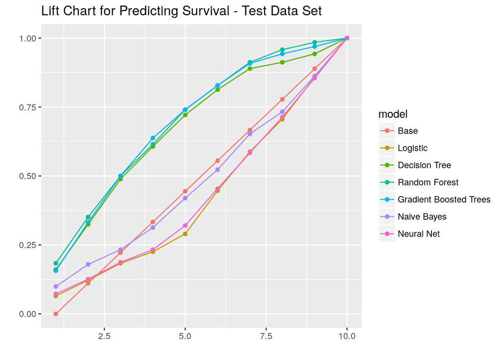

```r
# Lift function
calculate_lift <- function(scored_data) {
  scored_data %>%
    mutate(bin = ntile(desc(prediction), 10)) %>%
    group_by(bin) %>%
    summarize(count = sum(quality_bin)) %>%
    mutate(prop = count / sum(count)) %>%
    arrange(bin) %>%
    mutate(prop = cumsum(prop)) %>%
    select(-count) %>%
    collect() %>%
    as.data.frame()
}

# Initialize results
ml_gains <- data.frame(bin = 1:10, prop = seq(0, 1, len = 10), model = "Base")

# Calculate lift
for(i in names(ml_score)){
  ml_gains <- ml_score[[i]] %>%
    calculate_lift %>%
    mutate(model = i) %>%
    rbind(ml_gains, .)
}

# Plot results
ggplot(ml_gains, aes(x = bin, y = prop, colour = model)) +
  geom_point() + geom_line() +
  ggtitle("Lift Chart for Predicting Survival - Test Data Set") +
  xlab("") + ylab("")
```

#### AUC and accurary

Spark does not provide output for computing the ROC curve, but the Area under the ROC curve (AUC) is provided. The higher the AUC the better.

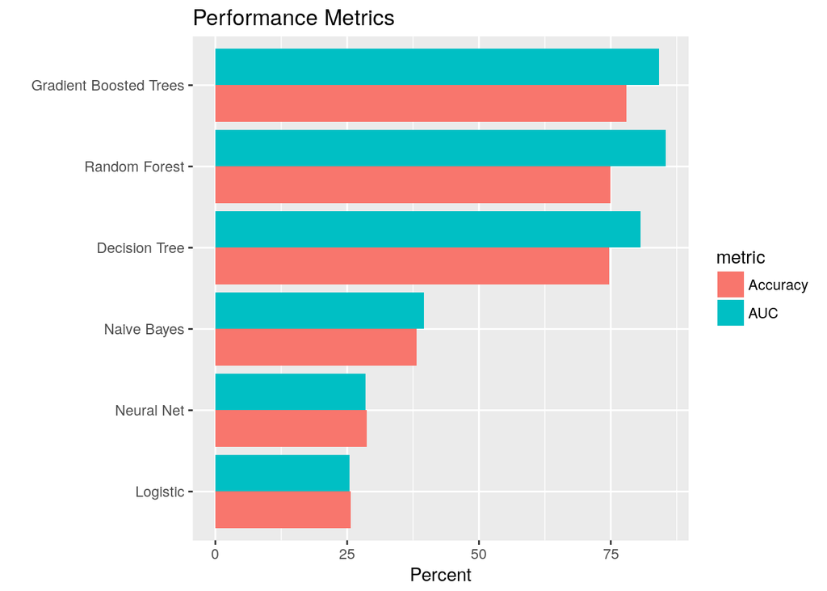

```r
# Function for calculating accuracy
calc_accuracy <- function(data, cutpoint = 0.5){
  data %>%
    mutate(prediction = if_else(prediction > cutpoint, 1.0, 0.0)) %>%
    ml_classification_eval("prediction", "quality_bin", "accuracy")
}

# Calculate AUC and accuracy
perf_metrics <- data.frame(
  model = names(ml_score),
  AUC = 100 * sapply(ml_score, ml_binary_classification_eval, "quality_bin", "prediction"),
  Accuracy = 100 * sapply(ml_score, calc_accuracy),
  row.names = NULL, stringsAsFactors = FALSE)

# Plot results
gather(perf_metrics, metric, value, AUC, Accuracy) %>%
  ggplot(aes(reorder(model, value), value, fill = metric)) +
  geom_bar(stat = "identity", position = "dodge") +
  coord_flip() +
  xlab("") +
  ylab("Percent") +
  ggtitle("Performance Metrics")
```

#### Feature importance

We now compare the features that were identified by each model as being important predictors for red wine quality. The logistic regression and tree models implement feature importance metrics, but only the tree models will be used here.

[output not shown]

```r
spark_disconnect(sc)
```